# data-day1-analyses

Jamil Bhanji and Vanessa Lobue

10/27/2021

## Zion’s Data

```r
#command to change data viewing preference to show more columns:
#rstudioapi::writeRStudioPreference("data_viewer_max_columns", 1000L)

zion_tib <- readr::read_delim(delim="\t",file="data/crichlowzion_52153_19605401_Zion-Crichlow-dataset.txt")
```

#### Hypothesis/Research Question 1

- what is the hypothesis examined? what columns are used to test the hypothesis
  - people have a stress response to their own violent behavior
  - girls will have a larger stress response to their own violent behavior
  - race?

##### Descriptives and examine distributions of relevant variables

1. Check cases and missing values, apply any exclusion criteria:
   - Are missing values appearing appropriately? (scan the table after importing)
   - How many full cases?
   - Are you concerned about missing data?
2. Mean, median, sd, min, max, cases for numeric variables of interest
3. Category counts for categoricals
4. Box plots, histograms for vars of interest (Q-Q plots if you want)

```r
# get descriptives for numerical vars
zion_tib %>% select(ss3.RAGtot,ss3.PTStot) %>%
  psych::describe() %>%
  knitr::kable(caption = "numerical variable descriptives", digits = 2) %>%
  kableExtra::kable_classic(lightable_options = "hover")
```

numerical variable descriptives

|  | vars | n | mean | sd | median | trimmed | mad | min | max | range | skew | kurtosis | se |
| --- | --- | --- | --- | --- | --- | --- | --- | --- | --- | --- | --- | --- | --- |
| ss3.RAGtot | 1 | 168 | 0.16 | 0.40 | 0.00 | 0.06 | 0.00 | 0 | 2 | 2 | 2.88 | 7.93 | 0.03 |
| ss3.PTStot | 2 | 168 | 1.32 | 0.73 | 1.33 | 1.32 | 0.82 | 0 | 3 | 3 | 0.05 | -0.86 | 0.06 |

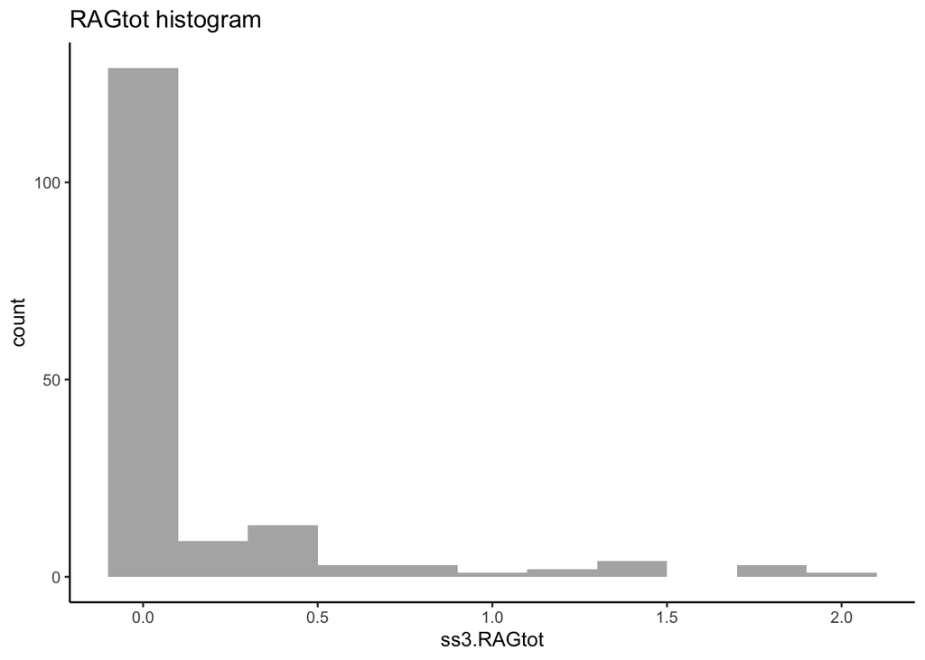

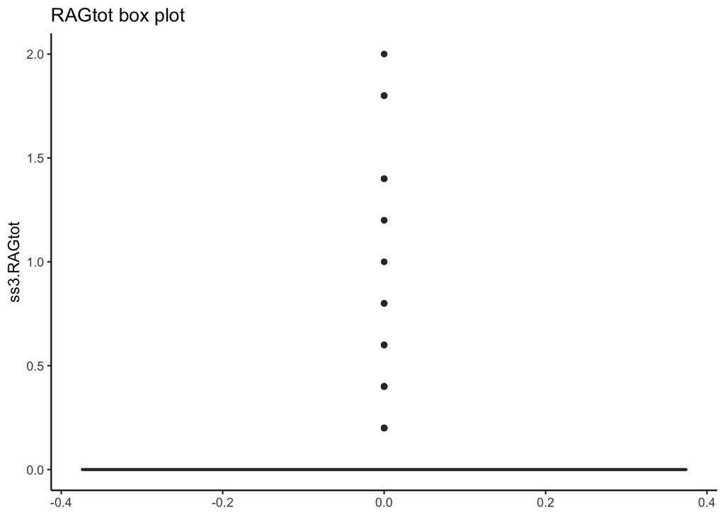

```r
# count categorical variables (example)
#zion_tib %>% count(ss1.Race)

# data visualization for relevant vars
p1 <- zion_tib %>% drop_na(ss3.RAGtot) %>%
  ggplot( aes(x=ss3.RAGtot)) +
    geom_histogram(position = "identity", binwidth = .2,
                   alpha = .5) +
    theme_classic() + labs (title = "RAGtot histogram")
p2 <- zion_tib %>% #drop_na() %>%
    ggplot( aes(y=ss3.RAGtot)) +
      geom_boxplot() +
      theme_classic() +
      labs (title = "RAGtot box plot")
p1; p2
```

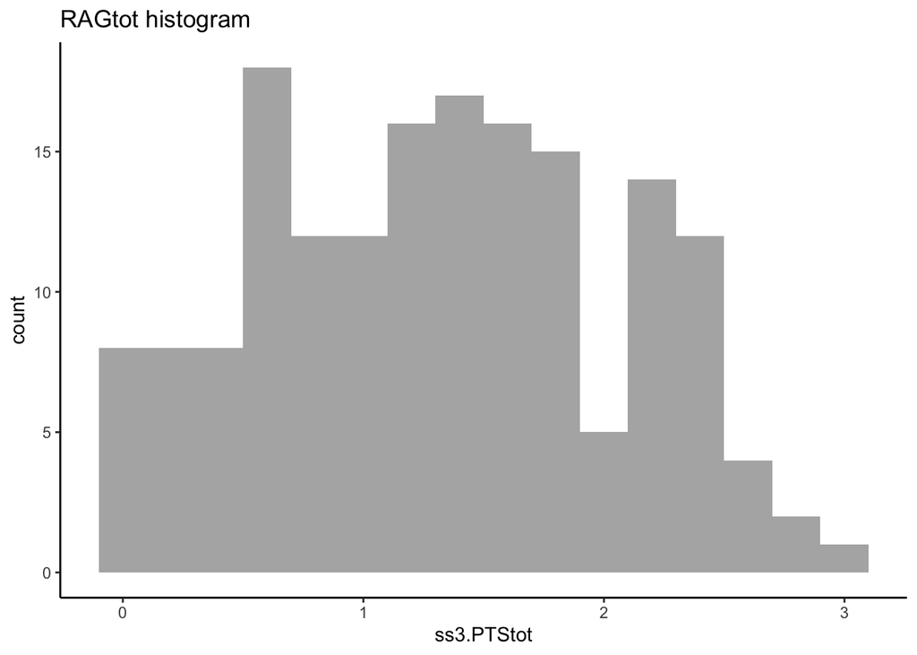

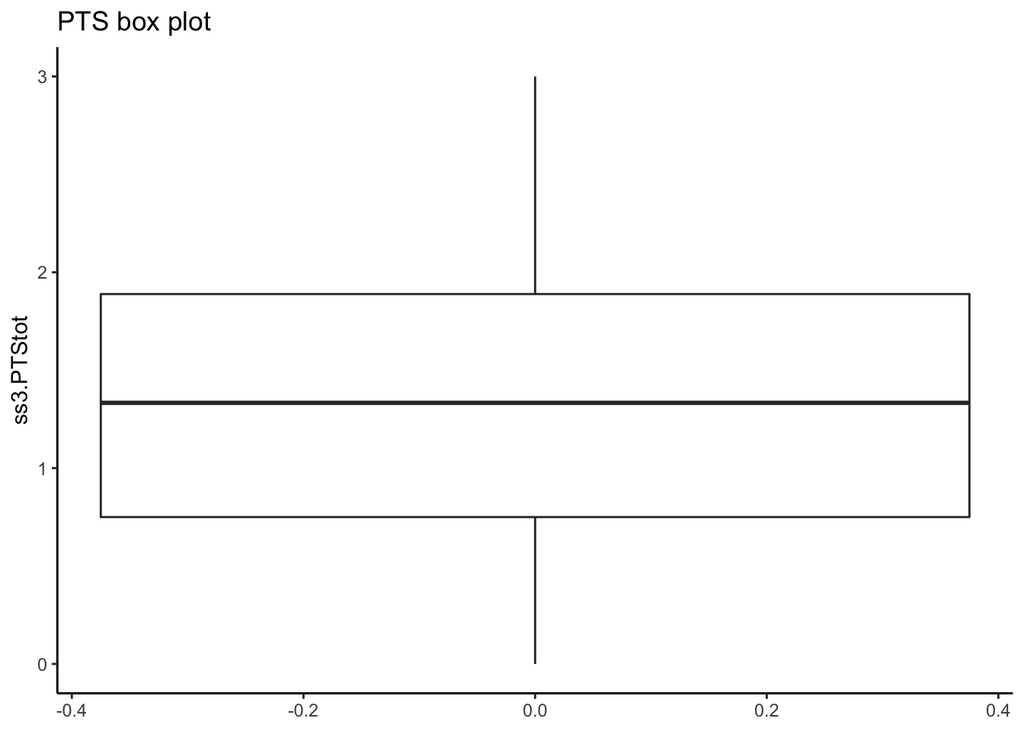

```r
p3 <- zion_tib %>% drop_na(ss3.PTStot) %>%
  ggplot( aes(x=ss3.PTStot)) +
    geom_histogram(position = "identity", binwidth = .2,
                   alpha = .5) +
    theme_classic() + labs (title = "RAGtot histogram")
p4 <- zion_tib %>% drop_na(ss3.PTStot) %>%
    ggplot( aes(y=ss3.PTStot)) +
      geom_boxplot() +
      theme_classic() +
      labs (title = "PTS box plot")
p3; p4
```

##### Statistical model

- outcome: stress response (ss3.PTStot)
- explanatory vars (predictors): violence at t3 (ss3.RAGtot)

```r
#statistical model
pts_lm <- zion_tib %>% drop_na(ss3.PTStot, ss3.RAGtot) %>%
  lm(formula = ss3.PTStot ~ ss3.RAGtot)
summary(pts_lm)
```

```
##
## Call:
## lm(formula = ss3.PTStot ~ ss3.RAGtot, data = .)
##
## Residuals:
##      Min       1Q   Median       3Q      Max
## -1.43743 -0.58978 -0.03422  0.54015  1.63244
##
## Coefficients:
##             Estimate Std. Error t value Pr(>|t|)
## (Intercept)  1.25645    0.06002  20.933   <2e-16 ***
## ss3.RAGtot   0.36737    0.14000   2.624   0.0095 **
## ---
## Signif. codes:  0 '***' 0.001 '**' 0.01 '*' 0.05 '.' 0.1 ' ' 1
##
## Residual standard error: 0.7186 on 166 degrees of freedom
## Multiple R-squared:  0.03983,    Adjusted R-squared:  0.03404
## F-statistic: 6.886 on 1 and 166 DF,  p-value: 0.0095
```

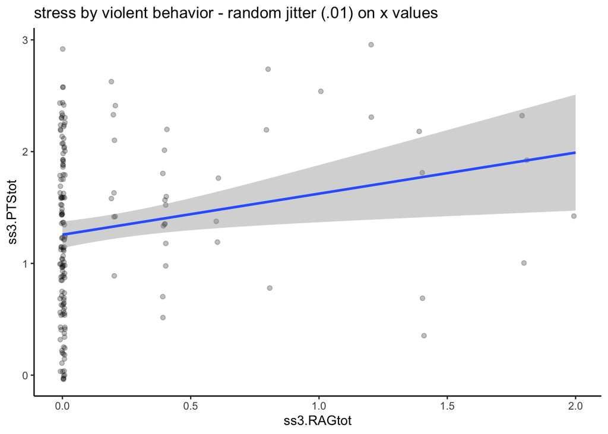

```r
#scatter plot with regression line - there are many points at x=0, so
#we will add a slight random jitter to the x values
p1z <- zion_tib %>% drop_na(ss3.PTStot, ss3.RAGtot) %>%
  ggplot( aes(x=ss3.RAGtot, y=ss3.PTStot)) +
    geom_point(alpha = .25, position = position_jitter(width=.01)) +
    geom_smooth(method = "lm", formula = y ~ x) +
    theme_classic() +
    labs(title="stress by violent behavior - random jitter (.01) on x values")
p1z
```

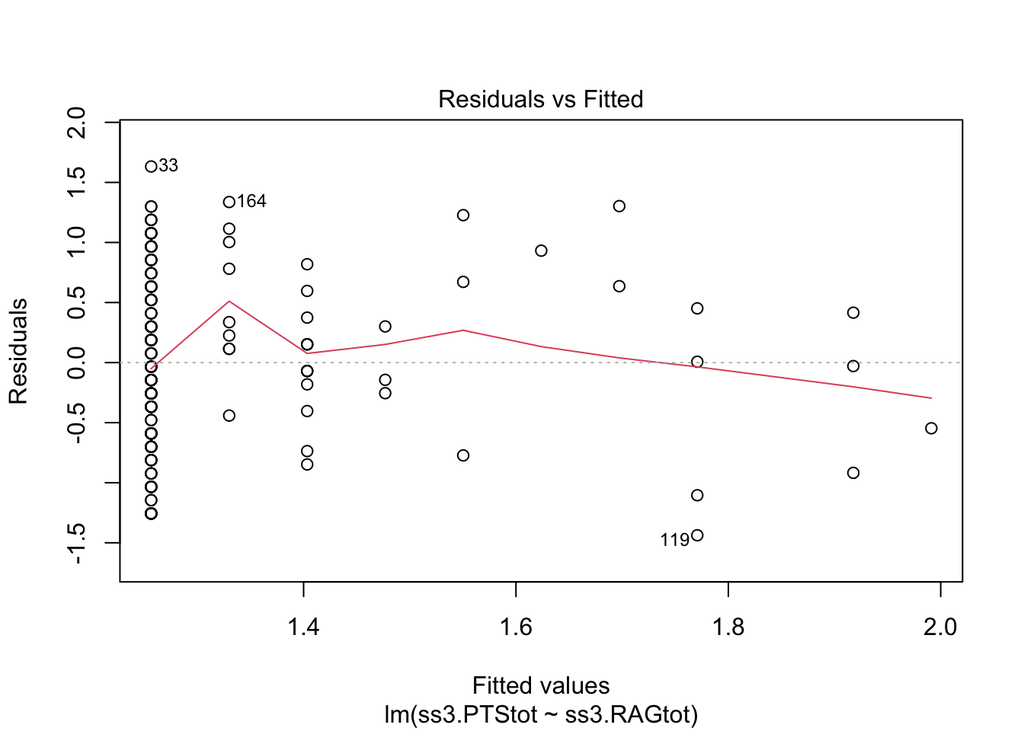

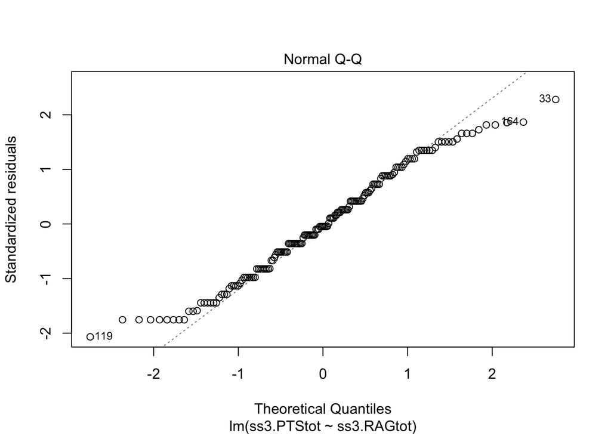

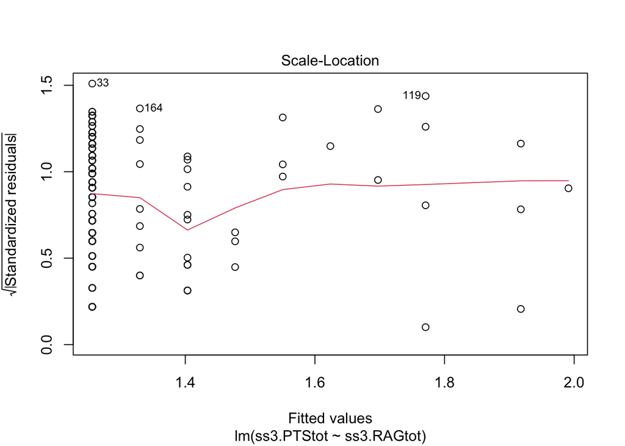

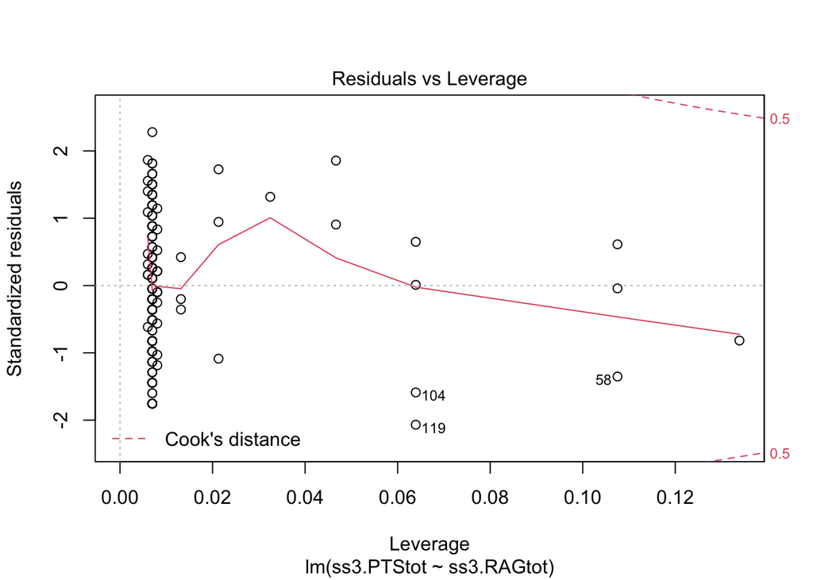

```r
#model diagnostics - residual plots
plot(pts_lm)
```

```r
zion_tib %>% drop_na(ss3.PTStot, ss3.RAGtot) %>%
  select(ss3.PTStot, ss3.RAGtot) %>%
  correlation::correlation(method = "pearson")
```

```
## # Correlation Matrix (pearson-method)
##
## Parameter1 | Parameter2 |    r |       95% CI | t(166) |       p
## ----------------------------------------------------------------
## ss3.PTStot | ss3.RAGtot | 0.20 | [0.05, 0.34] |   2.62 | 0.009**
##
## p-value adjustment method: Holm (1979)
## Observations: 168
```

```r
zion_tib %>% drop_na(ss3.PTStot, ss3.RAGtot) %>%
  select(ss3.PTStot, ss3.RAGtot) %>%
  correlation::correlation(method = "kendall")
```

```
## # Correlation Matrix (kendall-method)
##
## Parameter1 | Parameter2 |  tau |       95% CI |    z |       p
## --------------------------------------------------------------
## ss3.PTStot | ss3.RAGtot | 0.19 | [0.09, 0.29] | 3.11 | 0.002**
##
## p-value adjustment method: Holm (1979)
## Observations: 168
```

- linear model - positive relation between violence and stress
  - explore zeros in violent behavior
  - for further analysis explore gender

## Cory’s data

```r
# import data
cory_tib <- readr::read_delim(
  "data/mccabecorym_344360_19967879_SRS_scores_og.txt",
  delim = "\t")
cory_tib <- cory_tib %>%
  dplyr::mutate(
    ASD_fac = forcats::as_factor(ASD)
  ) %>%
  dplyr::select(PID,ASD,ASD_fac,SRS_total:SRS_com)
```

#### Hypothesis/Research Question 1

- what is the hypothesis examined? what columns are used to test the hypothesis
  - Social impairment (SRS_total) is related ASD status

##### Descriptives and examine distributions of relevant variables

1. Check cases and missing values, apply any exclusion criteria:
   - Are missing values appearing appropriately? (scan the table after importing)
   - How many full cases?
   - Are you concerned about missing data?
2. Mean, median, sd, min, max, cases for numeric variables of interest
3. Category counts for categoricals
4. Box plots, histograms for vars of interest (Q-Q plots if you want)

```r
# get descriptives for numerical vars
cory_tib %>% select(SRS_total:SRS_com) %>%
  psych::describe() %>%
  knitr::kable(caption = "SRS descriptives", digits = 2) %>%
  kableExtra::kable_classic(lightable_options = "hover")
```

SRS descriptives

|  | vars | n | mean | sd | median | trimmed | mad | min | max | range | skew | kurtosis | se |
| --- | --- | --- | --- | --- | --- | --- | --- | --- | --- | --- | --- | --- | --- |
| SRS_total | 1 | 36 | 133.47 | 22.69 | 128 | 132.70 | 18.53 | 89 | 189 | 100 | 0.43 | -0.29 | 3.78 |
| SRS_cog | 2 | 36 | 25.94 | 4.22 | 26 | 25.97 | 2.97 | 17 | 35 | 18 | -0.06 | -0.32 | 0.70 |
| SRS_com | 3 | 36 | 38.92 | 6.87 | 38 | 38.70 | 5.93 | 24 | 56 | 32 | 0.29 | -0.18 | 1.14 |

```r
# count categorical variables (example)
cory_tib %>% count(ASD_fac)
```

```
## # A tibble: 2 x 2
##   ASD_fac     n
## * <fct>   <int>
## 1 0          21
## 2 1          15
```

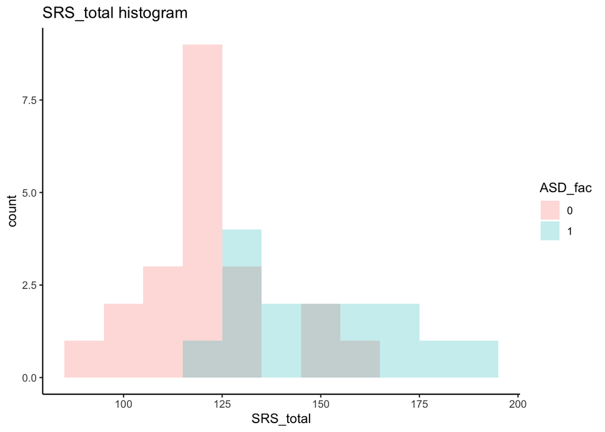

```r
# data visualization for relevant vars
p1c <- cory_tib %>% #drop_na() %>%
  ggplot( aes(x=SRS_total, fill = ASD_fac)) +
    geom_histogram(position = "identity", binwidth = 10, alpha = .25) +
    theme_classic() + labs (title = "SRS_total histogram")
p1c
```

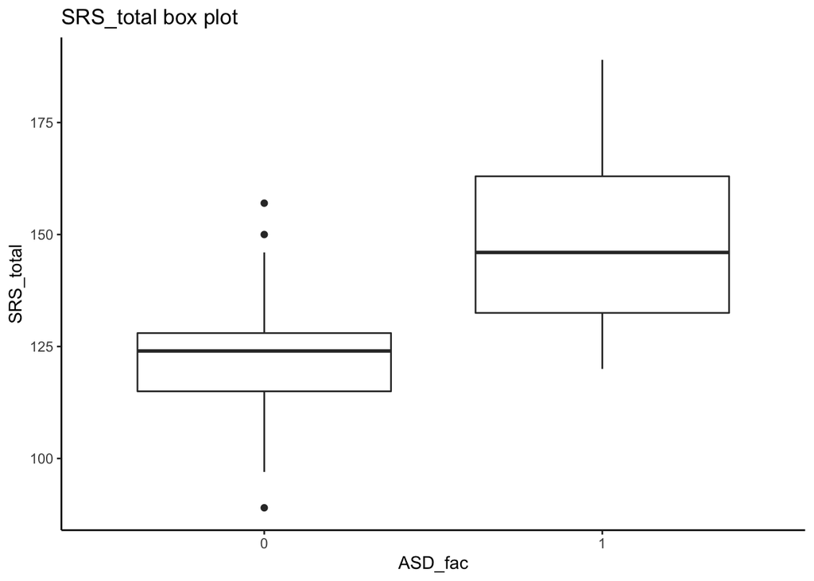

```r
p2c <- cory_tib %>% #drop_na() %>%
    ggplot( aes(y=SRS_total, x = ASD_fac)) + geom_boxplot() + theme_classic() +
      labs (title = "SRS_total box plot")
p2c
```

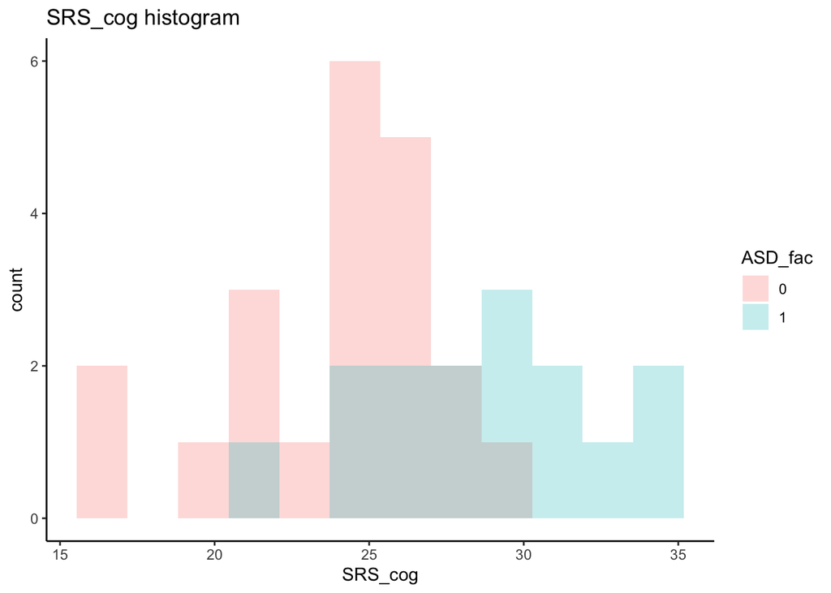

```r
p3c <- cory_tib %>% #drop_na() %>%
  ggplot( aes(x=SRS_cog, fill = ASD_fac)) +
    geom_histogram(position = "identity", bins = 12, alpha = .25) +
    theme_classic() + labs (title = "SRS_cog histogram")
p3c
```

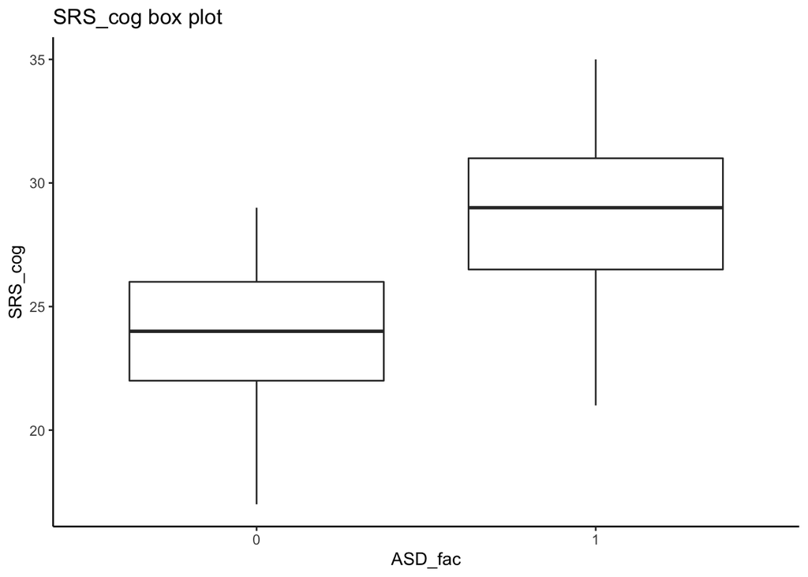

```r
p4c <- cory_tib %>% #drop_na() %>%
    ggplot( aes(y=SRS_cog, x = ASD_fac)) + geom_boxplot() + theme_classic() +
      labs (title = "SRS_cog box plot")
p4c
```

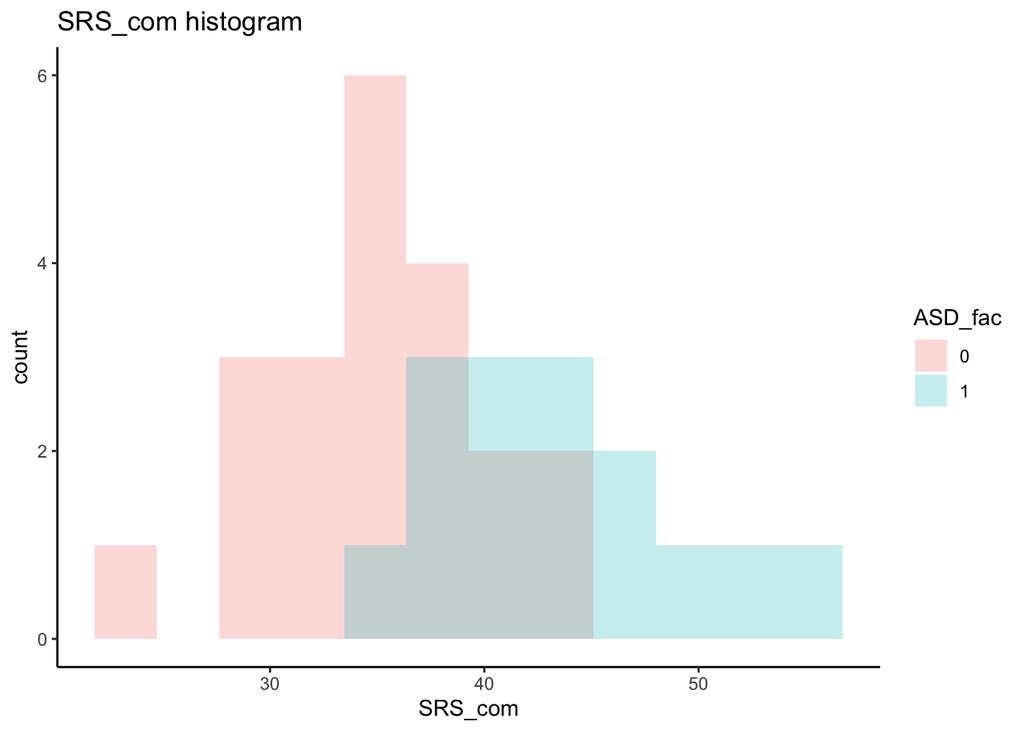

```r
p5c <- cory_tib %>% #drop_na() %>%
  ggplot( aes(x=SRS_com, fill = ASD_fac)) +
    geom_histogram(position = "identity", bins = 12, alpha = .25) +
    theme_classic() + labs (title = "SRS_com histogram")
p5c
```

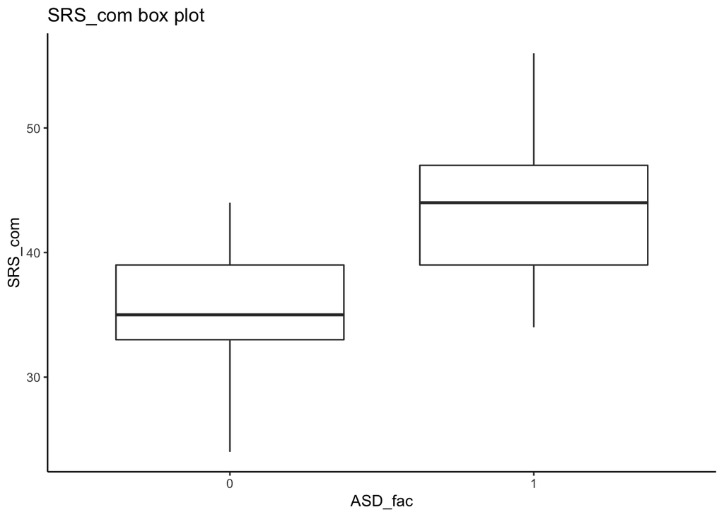

```r
p6c <- cory_tib %>% #drop_na() %>%
    ggplot( aes(y=SRS_com, x = ASD_fac)) + geom_boxplot() + theme_classic() +
      labs (title = "SRS_com box plot")
p6c
```

##### Statistical model

- mean SRS_total for ASD compared to no ASD
- alternatively, logistic regression with ASD predicted by SRS_total

```r
# t-test of means for two groups:
cat("SRS_total t-test:\n")
```

```
## SRS_total t-test:
```

```r
cory_tib %>% t.test(formula= SRS_total ~ ASD_fac,
                    data = .,
                    paired = FALSE,
                    alternative = "two.sided",
                    var.equal = FALSE
                    )
```

```
##
##  Welch Two Sample t-test
##
## data:  SRS_total by ASD_fac
## t = -4.4191, df = 26.408, p-value = 0.0001511
## alternative hypothesis: true difference in means is not equal to 0
## 95 percent confidence interval:
##  -41.00036 -14.98060
## sample estimates:
## mean in group 0 mean in group 1
##        121.8095        149.8000
```

```r
cat("\nSRS_cog t-test:\n")
```

```
##
## SRS_cog t-test:
```

```r
cory_tib %>% t.test(formula= SRS_cog ~ ASD_fac,
                    data = .,
                    paired = FALSE,
                    alternative = "two.sided",
                    var.equal = FALSE
                    )
```

```
##
##  Welch Two Sample t-test
##
## data:  SRS_cog by ASD_fac
## t = -4.08, df = 28.42, p-value = 0.0003315
## alternative hypothesis: true difference in means is not equal to 0
## 95 percent confidence interval:
##  -7.351302 -2.439174
## sample estimates:
## mean in group 0 mean in group 1
##        23.90476        28.80000
```

```r
cat("SRS_com t-test:\n")
```

```
## SRS_com t-test:
```

```r
cory_tib %>% t.test(formula= SRS_com ~ ASD_fac,
                    data = .,
                    paired = FALSE,
                    alternative = "two.sided",
                    var.equal = FALSE
                    )
```

```
##
##  Welch Two Sample t-test
##
## data:  SRS_com by ASD_fac
## t = -4.253, df = 26.739, p-value = 0.0002297
## alternative hypothesis: true difference in means is not equal to 0
## 95 percent confidence interval:
##  -12.242524  -4.271762
## sample estimates:
## mean in group 0 mean in group 1
##        35.47619        43.73333
```

```r
# effect sizes
cat("SRS_total cohens d:\n")
```

```
## SRS_total cohens d:
```

```r
effectsize::cohens_d(SRS_total ~ ASD_fac,
                     data = cory_tib,
                     pooled_sd = TRUE,
                     paired = FALSE)
```

```
## Cohen's d |         95% CI
## --------------------------
## -1.55     | [-2.29, -0.78]
##
## - Estimated using pooled SD.
```

```r
cat("\nSRS_cog cohens d:\n")
```

```
##
## SRS_cog cohens d:
```

```r
effectsize::cohens_d(SRS_cog ~ ASD_fac,
                     data = cory_tib,
                     pooled_sd = TRUE,
                     paired = FALSE)
```

```
## Cohen's d |         95% CI
## --------------------------
## -1.40     | [-2.14, -0.65]
##
## - Estimated using pooled SD.
```

```r
cat("\nSRS_com cohens d:\n")
```

```
##
## SRS_com cohens d:
```

```r
effectsize::cohens_d(SRS_com ~ ASD_fac,
                     data = cory_tib,
                     pooled_sd = TRUE,
                     paired = FALSE)
```

```
## Cohen's d |         95% CI
## --------------------------
## -1.48     | [-2.22, -0.72]
##
## - Estimated using pooled SD.
```

```r
cat("\n")
```